# CEE218X Assignment 1

Ximena Hasbach

10/18/2020

```
## [1] "PGE_2017_Q1_ElectricUsageByZip.csv"
## [1] "PGE_2017_Q2_ElectricUsageByZip.csv"
## [1] "PGE_2017_Q3_ElectricUsageByZip.csv"
## [1] "PGE_2017_Q4_ElectricUsageByZip.csv"
## [1] "PGE_2018_Q1_ElectricUsageByZip.csv"
## [1] "PGE_2018_Q2_ElectricUsageByZip.csv"
## [1] "PGE_2018_Q3_ElectricUsageByZip.csv"
## [1] "PGE_2018_Q4_ElectricUsageByZip.csv"
## [1] "PGE_2019_Q1_ElectricUsageByZip.csv"
## [1] "PGE_2019_Q2_ElectricUsageByZip.csv"
## [1] "PGE_2019_Q3_ElectricUsageByZip.csv"
## [1] "PGE_2019_Q4_ElectricUsageByZip.csv"
## [1] "PGE_2020_Q1_ElectricUsageByZip.csv"
## [1] "PGE_2020_Q2_ElectricUsageByZip.csv"
## [1] "PGE_2020_Q3_ElectricUsageByZip.csv"
```

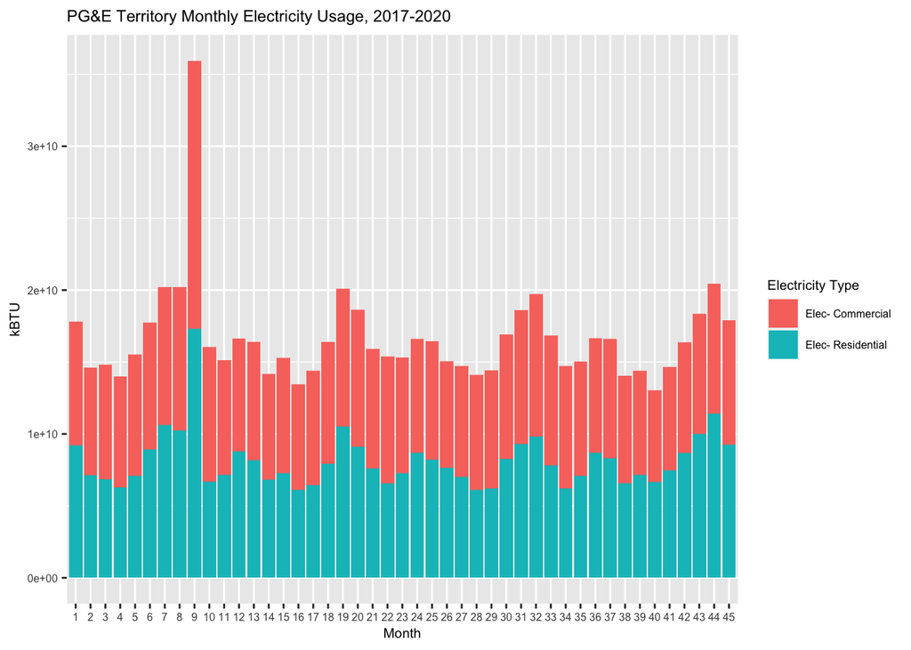

The PG&E Electricity Usage chart above has an x-axis showing the month number, from 1-45, representing January 2017-September 2020. We can see from the kBTU of electricity used each month in the years 2017-2020, electricity use overall (commercial and residential combined) peaks in the summer months, particularly July and August. The overall electricity use dips in April of each year. There is an outlier in September of 2017, where the commercial and residential values are both much higher than average. This is likely an error. There is not an obvious change in electricity use due to the COVID-19 pandemic.

Gas chart:

```
## [1] "PGE_2017_Q1_GasUsageByZip.csv"
## [1] "PGE_2017_Q2_GasUsageByZip.csv"
## [1] "PGE_2017_Q3_GasUsageByZip.csv"
## [1] "PGE_2017_Q4_GasUsageByZip.csv"
## [1] "PGE_2018_Q1_GasUsageByZip.csv"
## [1] "PGE_2018_Q2_GasUsageByZip.csv"
## [1] "PGE_2018_Q3_GasUsageByZip.csv"
## [1] "PGE_2018_Q4_GasUsageByZip.csv"
## [1] "PGE_2019_Q1_GasUsageByZip.csv"
## [1] "PGE_2019_Q2_GasUsageByZip.csv"
## [1] "PGE_2019_Q3_GasUsageByZip.csv"
## [1] "PGE_2019_Q4_GasUsageByZip.csv"
## [1] "PGE_2020_Q1_GasUsageByZip.csv"
## [1] "PGE_2020_Q2_GasUsageByZip.csv"
## [1] "PGE_2020_Q3_GasUsageByZip.csv"
```

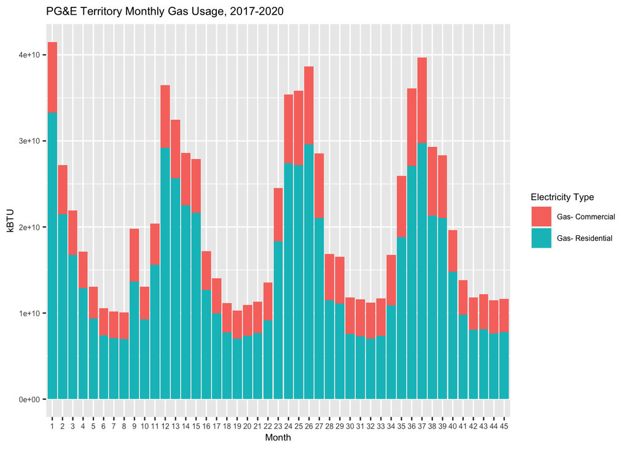

From the gas usage chart above, it is clear that the residential sector uses much more gas than the commercial sector. As opposed to the electricity use chart, here it seems like residential gas use is much greater than commercial gas use.

Overall chart:

```
## # A tibble: 76,079 x 10
## # Groups:   ZIPCODE, YEAR, MONTH [40,053]
##    ZIPCODE  YEAR MONTH CUSTOMERCLASS TOTALKWH TOTALCUSTOMERS AVERAGEKWH TOTALBTU
##      <dbl> <dbl> <dbl> <chr>            <dbl>          <dbl>      <dbl>    <dbl>
##  1   92356  2019    25 Elec- Reside…        0              0        NaN        0
##  2   92356  2019    26 Elec- Reside…        0              0        NaN        0
##  3   92356  2019    27 Elec- Reside…        0              0        NaN        0
##  4   92356  2019    28 Elec- Reside…        0              0        NaN        0
##  5   92356  2019    29 Elec- Reside…        0              0        NaN        0
##  6   92356  2019    30 Elec- Reside…        0              0        NaN        0
##  7   92356  2019    31 Elec- Reside…        0              0        NaN        0
##  8   92356  2019    32 Elec- Reside…        0              0        NaN        0
##  9   92356  2019    33 Elec- Reside…        0              0        NaN        0
## 10   92356  2019    34 Elec- Reside…        0              0        NaN        0
## # … with 76,069 more rows, and 2 more variables: TOTALTHM <dbl>,
## #   AVERAGETHM <dbl>
```

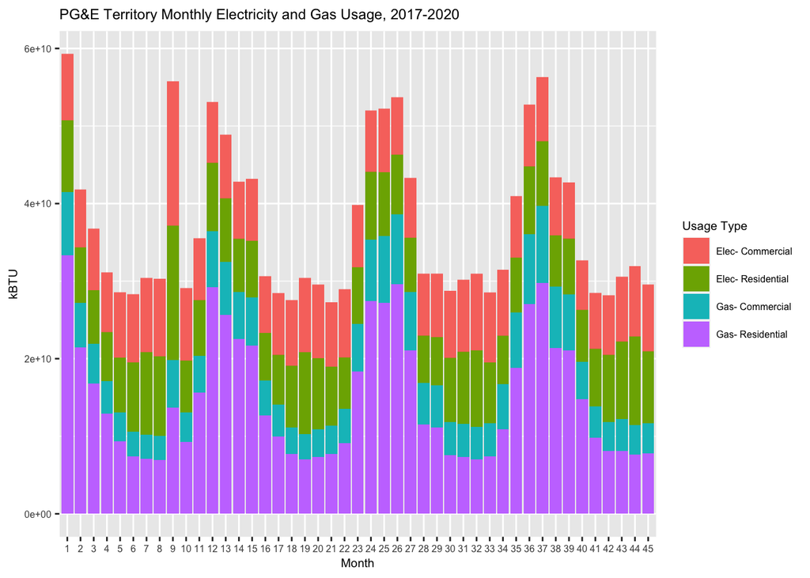

From the combined four-color chart, it looks like overall energy use peaks in the colder months, from around November through March, and dips in the summer months. There is not an obvious change to energy use patterns in 2020 due to the COVID-19 pandemic.

For the pre- and post-pandemic maps, I will create two data sets from the 2017-2020 electricity: The COVID dataset will be from February 2020-September 2020. The pre-COVID data will be from the February 2019- September 2019, in order to compare the same timespan. I have chosen these dates because the first coronavirus case in the United States was declared on January 21, 2020.

[output not shown]

[interactive chart not shown]